# Craps Simulator Shiny App

Dan Feldman

2023-11-10

# Overview

The [Craps Simulation Shiny App](https://danfeldman.shinyapps.io/CrapsSimulation/) simulates the casino dice game named craps. It is intended to assist players in developing optimal strategies for both betting and bankroll management for pass-line-bets-with-odds style of play. The simulator allows users to input four different parameters around betting style and game set-up

1. Minimum Bet Size
2. Maximum Bet Size
3. Bet Progression Size
4. Odds

Additionally, two parameters control features of the simulation itself.

1. Games
2. Simulations

All parameters will be explained in a later slide.

# How is Craps Played?

Craps can be played in a number of ways, but a common approach is to play the pass line with odds, which is the approach used by the simulator. In this approach, in a casino setting, a game of craps is played in two phases.

**Phase 1**

A player first places a bet on the [pass line](https://entertainment.howstuffworks.com/craps4.htm), a broad, L-shaped section at the base of craps layout. This is called the *pass line bet*.

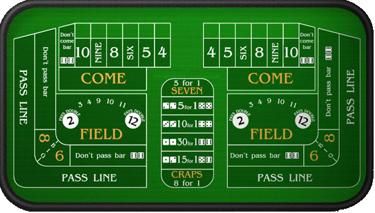

*image credit: lasvegasdirect.com* Two die are rolled. If the result is a 7 or 11, the game ends and the player is paid the *pass line bet* amount. If the result is a 2, 3 or 12, the game ends and the player loses the bet. For any other result (4,5,6,8,9,10), the result is called the *point* and play proceeds to phase 2.

**Phase 2**

In phase two, the player has the option of placing an additional bet on top of the pass line bet, as much as the allowed *odds* multiple (allowed odds are usually posted at the table). This is called the odds bet. For example, if a player makes a pass line bet for $5 and the odds are set to 5, the player may make an additional $25 bet. The dice are rolled. If the result is a 7, the player loses both bets. If the result is the *point*, the player is paid the amount of the *pass line bet* plus a multiple of the odds bet that depends on what the *point* was. If the result is neither the *point* nor a 7 the dice are rolled again. The dice continue to be rolled until the *point* or a 7 appears. The table below lists the payouts;

| Point | Odds Bet Payout |
| --- | --- |
| 6,8 | 1.2x |
| 5,9 | 1.5x |
| 4,10 | 2x |

# What Does the Simulator Do?

The simulator will simulate up to 5,000 games of craps and returns two basic statistics about the outcome: The amount of money won or lost and the house edge. The house edge is the amount won or lost as a proportion of the total amount wagered. For example, if the total amount of money wagered over 100 simulations equals $1,000 and the total amount lost is $100, the result is computed as:

$$-(\frac{-\$100}{\$1000}) * 100 =
10%$$

*Note: the equation is multiplied by -1 in order for the house edge for an outcome where money is lost to appear positive. Thus, a positive house edge means that the house won money in this simulation.*

The simulator also draws a nice graph of the action.

**Simulator Inputs**

`Starting Bet`: The size of the pass line bet. When a bet is lost, the bet size always reverts to this amount

`Bet Progression`: The amount by which the pass line bet will increase after a bet with odds is won

`Max Bet`: The maximum amount to which the pass line bet is allowed to increase. If `Bet Progression` is set to `0`, then `Max Bet = Starting Bet`

`Odds`: The multiple from which the odds bet will be calculated

`Number of Games`: The number of games to play for the simulation. Up to 5,000 games can be simulated. A “game” is an instance where a bet is resolved, either in phase 1 or 2.

`Number of Simulations`: The number of times to simulate the number of games selected. To allow for reasonable processing time, up to 20 simultaneous simulations are permitted.

**Style of Play**

The simulator plays a certain way. It always begins with the `Starting Bet`. If the `Starting Bet` is resolved (won or lost) in phase 1, the simulator continues placing the `Starting Bet`. If the game continues to phase 2, the simulator will place an additional wager (odds bet) calculated as the `Starting Bet` x `Odds`. If this bet is lost, the simulator continues to use the original `Starting Bet` for the next game. If the bet is won, the simulator adds the `Bet Progression` value to the `Starting Bet` and uses this summed value as its new `Starting Bet`. It will continue to follow this formula as long as bets with odds are won and the new `Starting Bet` does not exceed the `Max Bet`. At all times, once a bet placed with odds is lost, the simulator reverts back to the original `Starting Bet`.

**Odds Bet Rounding**

Odds bets are adjusted upward to the nearest dollar to avoid payouts in partial dollars when the bet is won. For example, if a $5 bet is placed on the pass line with a $25 odds bet, and the point is a 5, if the bet is won, the payout to the player would be $5 + $25 * 1.5 = $42.50. To avoid this, the simulator rounds the odds bet up to $26 so that the payout is $5 + $26 * 1.5 = $44.

# The Simulator in Action

Imagine the simulator is given the following inputs: `Starting Bet = 5`, `Bet Progression = 5`, `Max Bet = 25`, `Odds = 5`, `Number of Games = 5000`, `Number of Simulations = 2`. The simulator will grind through all 5,000 games, twice, store the results in a large table, and then plot the cumulative results. What’s going on behind the scenes?

The raw data from the simulation is stored in two data frames contained within a list called `data`. The first list element in `data` is a matrix with the results of each game. The second element in `data` contains matrix with the amount wagered. In both matrices, a column is a simulation and a row is a game.

```r
head(data[[1]])
```

```
##      [,1] [,2]
## [1,]    5  -30
## [2,]  -31  -30
## [3,]  -30   35
## [4,]  -30   10
## [5,]    5  -60
## [6,]  -31    5
```

```r
head(data[[2]])
```

```
##      [,1] [,2]
## [1,]    5   30
## [2,]   31   30
## [3,]   30   30
## [4,]   30   10
## [5,]    5   60
## [6,]   31    5
```

Next, cumulative results are computed for each simulation from the results matrix in `data`. The results are then pivoted and stored in a data frame called `graphics` where the game number is the first column, the simulation number is in the second column, and the cumulative result (named “value”) is in the third column.

```r
graphics <- data.frame(apply(data[[1]], 2, cumsum)) %>%
  mutate(game = row_number()) %>%
  select(game, everything()) %>%
  pivot_longer(names_to = "sim", cols = -game)

head(graphics)
```

```
## # A tibble: 6 × 3
##    game sim   value
##   <int> <chr> <dbl>
## 1     1 X1        5
## 2     1 X2      -30
## 3     2 X1      -26
## 4     2 X2      -60
## 5     3 X1      -56
## 6     3 X2      -25
```

A few summary values are calculated for display on the shiny app and the graph.

```r
#House Edge
house_edge <- sprintf("%1.2f%%", -sum(colSums(data[[1]]))/sum(colSums(data[[2]]))*100)
house_edge
```

```
## [1] "1.93%"
```

```r
#Average Result
avg_result <- mean(colSums(data[[1]]))
avg_result
```

```
## [1] -3438.5
```

```r
#Best Outcome
max_reward <- max(colSums(data[[1]]))
max_reward
```

```
## [1] -2704
```

```r
#Worst Outcome
max_risk <- min(colSums(data[[1]]))
max_risk
```

```
## [1] -4173
```

Now, the data is ready for plotting in ggplot. There are lots of ways to do this, but I like to show the cumulative results over each game as it gives a sense of the randomness of results. I also like to use the viridis scale because the colors are awesome!

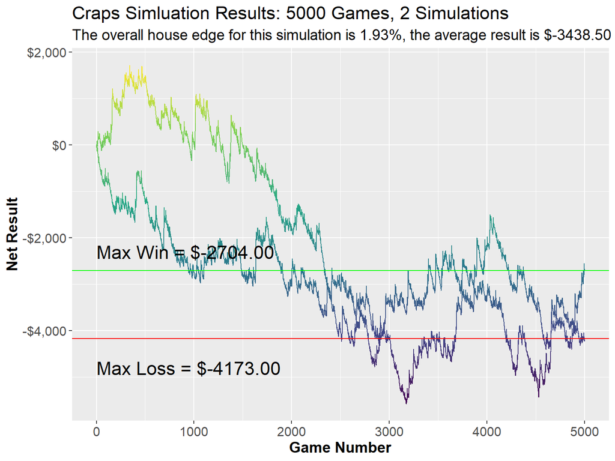

*What I’ve Learned* One thing that I’ve appreciated through building and using this app is that the law of large numbers sometimes requires a very large number of observations! Even through craps is a game with a well defined house edge (about 1.4% with no odds bets), there’s a lot of variability of results, even over a reasonable long stretch of time, like 1,000 games. To really get a sense of which parameters result in the best outcomes, one really needs to run many, many, MANY simulations and average those. Don’t just use one!

Try my app on [shinyapps.io](https://danfeldman.shinyapps.io/CrapsSimulation/)

Try the app out on my apps page!